# Final Group Project - AirBnB Analytics - Istanbul

# 3 Mapping

```r
leaflet(data = filter(istanbul_listings_final,
                      minimum_nights <= 4)) %>%
  addProviderTiles("OpenStreetMap.Mapnik") %>%
  addCircleMarkers(lng = ~longitude,
                   lat = ~latitude,
                   radius = 1,
                   fillColor = "#e6550d",
                   fillOpacity = 0.9,
                   popup = ~listing_url,
                   label = ~prop_type_simplified)
```

[interactive chart not shown]

# 4 Regression Analysis

We begin by omitting some variables that we will not be using in our regression analysis and converting character variables to factors.

In this section, we fit linear models to predict the total cost for 2 people to stay at the AirBnB property for 4 nights, in other words, the price_4_nights variable.

In the following subsections, we investigate the significance of various predictors for predicting this variable.

```r
regression_data <- istanbul_listings_final %>%

  #deselect variables not needed for the regression model
  select(-c(id,
            listing_url,
            latitude,
            longitude,
            neighbourhood,
            price,
            cleaning_fee_cleaned,
            extra_people_cleaned)) %>%

   #convert categorical variables to factors
  transform(room_type =as.factor(room_type),
            neighbourhood_cleansed = as.factor(neighbourhood_cleansed),
            neighbourhood_group_cleansed = as.factor(neighbourhood_group_cleansed),
            cancellation_policy = as.factor(cancellation_policy),
            prop_type_simplified = as.factor(prop_type_simplified))

#viewing the data frame for the regression
glimpse(regression_data)
```

```
## Rows: 8,738
## Columns: 18
## $ room_type                    <fct> Entire home/apt, Private room, Private...
## $ number_of_reviews            <dbl> 1, 1, 1, 9, 12, 86, 6, 3, 75, 18, 171,...
## $ review_scores_rating         <dbl> 100, 80, 100, 93, 95, 93, 100, 73, 90,...
## $ is_location_exact            <lgl> FALSE, FALSE, FALSE, FALSE, FALSE, FAL...
## $ neighbourhood_cleansed       <fct> Uskudar, Beyoglu, Sisli, Besiktas, Usk...
## $ neighbourhood_group_cleansed <fct> NA, NA, NA, NA, NA, NA, NA, NA, NA, NA...
## $ bathrooms                    <dbl> 1.0, 1.0, 1.0, 1.0, 1.5, 1.5, 1.0, 1.0...
## $ bedrooms                     <dbl> 0, 1, 1, 1, 2, 1, 1, 2, 3, 2, 1, 2, 1,...
## $ beds                         <dbl> 1, 1, 1, 2, 2, 1, 1, 2, 4, 2, 1, 3, 1,...
## $ host_identity_verified       <lgl> FALSE, TRUE, TRUE, FALSE, FALSE, TRUE,...
## $ host_is_superhost            <lgl> FALSE, FALSE, FALSE, FALSE, TRUE, FALS...
## $ accommodates                 <dbl> 2, 2, 2, 3, 4, 2, 2, 4, 6, 5, 3, 5, 2,...
## $ cancellation_policy          <fct> flexible, flexible, moderate, moderate...
## $ minimum_nights               <dbl> 1, 1, 2, 3, 3, 2, 2, 2, 3, 3, 3, 4, 1,...
## $ guests_included              <dbl> 2, 1, 2, 1, 2, 1, 1, 2, 4, 4, 2, 2, 1,...
## $ neighbourhood_group_cleaned  <chr> "Asian Side", "European Side", "Europe...
## $ prop_type_simplified         <fct> Apartment, Apartment, Apartment, Apart...
## $ price_4_nights               <dbl> 3058, 3226, 1959, 2365, 1913, 1099, 75...
```

## 4.1 Model 1

We first fit a linear model called model1 using prop_type_simplified, number_of_reviews, and review_scores_rating and plot the output and summary statistics to evaluate the significance of these variables as predictors. The key metrics that we will be examining to evaluate the above are: 1.R-squared adjusted: measurement of the extent of the variance of the outcome variable that is explained by the model. 2. P Values: indicates whether the independent explanatory variable is significant to the model (when below 0.05 it can be deemed significant). 3. T Stat: serves the same function as the P Value, suggesting whether the independent explanatory variable is significant to the model (when above 2 it can be deemed significant). 4. Variance Inflation Factor (VIFs): enable us to check for multicollinearity in our model. Since these are not provided in the summary table for the model, we will be computing this with the vif function in the car package.

```r
#Linear regression between price_4_night and prop_type_simplified, number_of_reviews, and review_scores_rating

model1<- lm(log(price_4_nights) ~ prop_type_simplified +
              number_of_reviews +
              review_scores_rating,
            data=regression_data)

#Look at model result

msummary(model1)
```

```
##                                          Estimate Std. Error t value Pr(>|t|)
## (Intercept)                             6.9411945  0.0551407 125.882  < 2e-16
## prop_type_simplifiedCondominium        -0.0312705  0.0585674  -0.534   0.5934
## prop_type_simplifiedHostel             -0.6704578  0.1037358  -6.463 1.08e-10
## prop_type_simplifiedHouse              -0.0162896  0.0360457  -0.452   0.6513
## prop_type_simplifiedOther               0.0552588  0.0213598   2.587   0.0097
## prop_type_simplifiedServiced apartment  0.1661304  0.0301407   5.512 3.65e-08
## number_of_reviews                       0.0010481  0.0002386   4.392 1.13e-05
## review_scores_rating                    0.0012725  0.0005888   2.161   0.0307
##
## (Intercept)                            ***
## prop_type_simplifiedCondominium
## prop_type_simplifiedHostel             ***
## prop_type_simplifiedHouse
## prop_type_simplifiedOther              **
## prop_type_simplifiedServiced apartment ***
## number_of_reviews                      ***
## review_scores_rating                   *
##
## Residual standard error: 0.7516 on 8730 degrees of freedom
## Multiple R-squared:  0.01157,    Adjusted R-squared:  0.01078
## F-statistic:  14.6 on 7 and 8730 DF,  p-value: < 2.2e-16
```

```r
#Check VIF

car::vif(model1)
```

```
##                          GVIF Df GVIF^(1/(2*Df))
## prop_type_simplified 1.025865  5        1.002557
## number_of_reviews    1.014591  1        1.007269
## review_scores_rating 1.024424  1        1.012138
```

We will add as well an example of interpretation of our data in logarithmic lm model.

## 4.2 Model 2

```r
#Add room_type in to linear regression model.

model2<- lm(log(price_4_nights) ~ prop_type_simplified +
              number_of_reviews +
              review_scores_rating +
              room_type,
            data=regression_data)

#Look at model result

msummary(model2)
```

```
##                                          Estimate Std. Error t value Pr(>|t|)
## (Intercept)                             7.1344052  0.0494444 144.291  < 2e-16
## prop_type_simplifiedCondominium         0.0570836  0.0522914   1.092 0.275020
## prop_type_simplifiedHostel             -0.1841026  0.0975161  -1.888 0.059070
## prop_type_simplifiedHouse               0.0361273  0.0321798   1.123 0.261608
## prop_type_simplifiedOther               0.2870094  0.0213459  13.446  < 2e-16
## prop_type_simplifiedServiced apartment  0.1031372  0.0274409   3.759 0.000172
## number_of_reviews                      -0.0002176  0.0002148  -1.013 0.310956
## review_scores_rating                    0.0016330  0.0005263   3.103 0.001923
## room_typeHotel room                    -0.2619629  0.0350657  -7.471 8.75e-14
## room_typePrivate room                  -0.7795214  0.0169951 -45.867  < 2e-16
## room_typeShared room                   -1.0869713  0.0737291 -14.743  < 2e-16
##
## (Intercept)                            ***
## prop_type_simplifiedCondominium
## prop_type_simplifiedHostel             .
## prop_type_simplifiedHouse
## prop_type_simplifiedOther              ***
## prop_type_simplifiedServiced apartment ***
## number_of_reviews
## review_scores_rating                   **
## room_typeHotel room                    ***
## room_typePrivate room                  ***
## room_typeShared room                   ***
##
## Residual standard error: 0.6706 on 8727 degrees of freedom
## Multiple R-squared:  0.2134, Adjusted R-squared:  0.2125
## F-statistic: 236.8 on 10 and 8727 DF,  p-value: < 2.2e-16
```

```r
#Check VIF

car::vif(model2)
```

```
##                          GVIF Df GVIF^(1/(2*Df))
## prop_type_simplified 1.459529  5        1.038535
## number_of_reviews    1.032395  1        1.016068
## review_scores_rating 1.028297  1        1.014050
## room_type            1.462462  3        1.065403
```

The room_type has increased our adjusted R-squared up to 21.3%. The p-value for each room type is less than 0.05, thus the room type variable is important and we will keep it in our model.

## 4.3 Model 3

We consider whether the number bathrooms, bedrooms, beds, or size of the house (accommodates) can be significant predictors of price_4_nights.

```r
#Continually add bathrooms, beds, bedrooms and the size of the house in to linear regression model

model3 <-lm(log(price_4_nights)~prop_type_simplified +
              number_of_reviews +
              room_type +
              bathrooms +
              bedrooms +
              beds +
              accommodates,
            data=regression_data)

#Look at model result

msummary(model3)
```

```
##                                          Estimate Std. Error t value Pr(>|t|)
## (Intercept)                             6.7419291  0.0176000 383.065  < 2e-16
## prop_type_simplifiedCondominium         0.0068847  0.0480722   0.143  0.88612
## prop_type_simplifiedHostel             -0.5122397  0.0907311  -5.646 1.70e-08
## prop_type_simplifiedHouse              -0.0109773  0.0296253  -0.371  0.71099
## prop_type_simplifiedOther               0.2284517  0.0196904  11.602  < 2e-16
## prop_type_simplifiedServiced apartment  0.0808172  0.0252140   3.205  0.00135
## number_of_reviews                      -0.0000395  0.0001970  -0.200  0.84112
## room_typeHotel room                    -0.0585488  0.0326770  -1.792  0.07321
## room_typePrivate room                  -0.5495409  0.0167768 -32.756  < 2e-16
## room_typeShared room                   -0.9081582  0.0679404 -13.367  < 2e-16
## bathrooms                              -0.0279060  0.0106273  -2.626  0.00866
## bedrooms                                0.0421745  0.0094802   4.449 8.75e-06
## beds                                   -0.0022568  0.0049818  -0.453  0.65055
## accommodates                            0.1233714  0.0046088  26.769  < 2e-16
##
## (Intercept)                            ***
## prop_type_simplifiedCondominium
## prop_type_simplifiedHostel             ***
## prop_type_simplifiedHouse
## prop_type_simplifiedOther              ***
## prop_type_simplifiedServiced apartment **
## number_of_reviews
## room_typeHotel room                    .
## room_typePrivate room                  ***
## room_typeShared room                   ***
## bathrooms                              **
## bedrooms                               ***
## beds
## accommodates                           ***
##
## Residual standard error: 0.6164 on 8718 degrees of freedom
##   (6 observations deleted due to missingness)
## Multiple R-squared:  0.3355, Adjusted R-squared:  0.3345
## F-statistic: 338.6 on 13 and 8718 DF,  p-value: < 2.2e-16
```

```r
#Check VIF

car::vif(model3)
```

```
##                          GVIF Df GVIF^(1/(2*Df))
## prop_type_simplified 1.502183  5        1.041531
## number_of_reviews    1.027533  1        1.013673
## room_type            1.694433  3        1.091870
## bathrooms            2.422508  1        1.556441
## bedrooms             3.230427  1        1.797339
## beds                 2.086114  1        1.444339
## accommodates         2.247987  1        1.499329
```

## 4.4 Model 4

We further consider whether superhosts (host_is_superhost) will influence our model.

```r
model4 <-lm(log(price_4_nights)~prop_type_simplified +
              number_of_reviews+
              room_type+
              bathrooms+
              bedrooms+
              accommodates+
              host_is_superhost,
            data=regression_data)

#Look at model result

msummary(model4)
```

```
##                                          Estimate Std. Error t value Pr(>|t|)
## (Intercept)                             6.7157430  0.0177560 378.224  < 2e-16
## prop_type_simplifiedCondominium         0.0202973  0.0478924   0.424  0.67171
## prop_type_simplifiedHostel             -0.5404653  0.0899689  -6.007 1.96e-09
## prop_type_simplifiedHouse              -0.0111029  0.0294979  -0.376  0.70663
## prop_type_simplifiedOther               0.2331259  0.0196141  11.886  < 2e-16
## prop_type_simplifiedServiced apartment  0.0990831  0.0251835   3.934 8.40e-05
## number_of_reviews                      -0.0003579  0.0001996  -1.793  0.07301
## room_typeHotel room                    -0.0397476  0.0326099  -1.219  0.22292
## room_typePrivate room                  -0.5412991  0.0167209 -32.373  < 2e-16
## room_typeShared room                   -0.8990517  0.0676212 -13.295  < 2e-16
## bathrooms                              -0.0296664  0.0105459  -2.813  0.00492
## bedrooms                                0.0418043  0.0092479   4.520 6.25e-06
## accommodates                            0.1215454  0.0040402  30.084  < 2e-16
## host_is_superhostTRUE                   0.1426748  0.0164987   8.648  < 2e-16
##
## (Intercept)                            ***
## prop_type_simplifiedCondominium
## prop_type_simplifiedHostel             ***
## prop_type_simplifiedHouse
## prop_type_simplifiedOther              ***
## prop_type_simplifiedServiced apartment ***
## number_of_reviews                      .
## room_typeHotel room
## room_typePrivate room                  ***
## room_typeShared room                   ***
## bathrooms                              **
## bedrooms                               ***
## accommodates                           ***
## host_is_superhostTRUE                  ***
##
## Residual standard error: 0.6138 on 8718 degrees of freedom
##   (6 observations deleted due to missingness)
## Multiple R-squared:  0.3411, Adjusted R-squared:  0.3401
## F-statistic: 347.2 on 13 and 8718 DF,  p-value: < 2.2e-16
```

```r
#Check VIF

car::vif(model4)
```

```
##                          GVIF Df GVIF^(1/(2*Df))
## prop_type_simplified 1.500187  5        1.041393
## number_of_reviews    1.063720  1        1.031368
## room_type            1.700828  3        1.092555
## bathrooms            2.405931  1        1.551106
## bedrooms             3.100378  1        1.760789
## accommodates         1.742288  1        1.319957
## host_is_superhost    1.065430  1        1.032197
```

Superhosts commands a pricing premium in Istanbul because the p-value is less htan 0.05, therefore we will keep this variable in our further models.

## 4.5 Model 5

Most owners advertise the exact location of their listing (is_location_exact == TRUE), while a non-trivial proportion don’t. After controlling for other variables, we consider whether a listing’s exact location can be a significant predictor of price_4_nights.

```r
model5 <-lm(log(price_4_nights)~prop_type_simplified +
              number_of_reviews+
              room_type+
              bathrooms+
              bedrooms+
              accommodates+
              host_is_superhost+
              is_location_exact,
            data=regression_data)

#Look at model result

msummary(model5)
```

```
##                                          Estimate Std. Error t value Pr(>|t|)
## (Intercept)                             6.7008090  0.0185180 361.854  < 2e-16
## prop_type_simplifiedCondominium         0.0208949  0.0478737   0.436 0.662515
## prop_type_simplifiedHostel             -0.5400252  0.0899329  -6.005 1.99e-09
## prop_type_simplifiedHouse              -0.0096018  0.0294909  -0.326 0.744745
## prop_type_simplifiedOther               0.2304678  0.0196288  11.741  < 2e-16
## prop_type_simplifiedServiced apartment  0.0971480  0.0251827   3.858 0.000115
## number_of_reviews                      -0.0003559  0.0001996  -1.784 0.074518
## room_typeHotel room                    -0.0447896  0.0326456  -1.372 0.170100
## room_typePrivate room                  -0.5392656  0.0167297 -32.234  < 2e-16
## room_typeShared room                   -0.8978775  0.0675953 -13.283  < 2e-16
## bathrooms                              -0.0299939  0.0105423  -2.845 0.004450
## bedrooms                                0.0427129  0.0092498   4.618 3.94e-06
## accommodates                            0.1213608  0.0040391  30.046  < 2e-16
## host_is_superhostTRUE                   0.1398170  0.0165230   8.462  < 2e-16
## is_location_exactTRUE                   0.0381333  0.0134858   2.828 0.004700
##
## (Intercept)                            ***
## prop_type_simplifiedCondominium
## prop_type_simplifiedHostel             ***
## prop_type_simplifiedHouse
## prop_type_simplifiedOther              ***
## prop_type_simplifiedServiced apartment ***
## number_of_reviews                      .
## room_typeHotel room
## room_typePrivate room                  ***
## room_typeShared room                   ***
## bathrooms                              **
## bedrooms                               ***
## accommodates                           ***
## host_is_superhostTRUE                  ***
## is_location_exactTRUE                  **
##
## Residual standard error: 0.6136 on 8717 degrees of freedom
##   (6 observations deleted due to missingness)
## Multiple R-squared:  0.3417, Adjusted R-squared:  0.3407
## F-statistic: 323.2 on 14 and 8717 DF,  p-value: < 2.2e-16
```

```r
#Check VIF

car::vif(model5)
```

```
##                          GVIF Df GVIF^(1/(2*Df))
## prop_type_simplified 1.505272  5        1.041745
## number_of_reviews    1.063734  1        1.031375
## room_type            1.712291  3        1.093779
## bathrooms            2.406221  1        1.551200
## bedrooms             3.104124  1        1.761853
## accommodates         1.742743  1        1.320130
## host_is_superhost    1.069431  1        1.034133
## is_location_exact    1.018479  1        1.009197
```

The variable “is_location_exact” can be a relatively significant factor because its p-value is also less than 0.05, although adding it has few influences on the adjusted R sqaure. And we can keep it.

## 4.6 Model 6

Now we consider the effect of cancellation_policy on price_4_nights, after we control for other variables.

```r
model6 <-lm(log(price_4_nights)~prop_type_simplified +
              number_of_reviews+
              room_type+
              bathrooms+
              bedrooms+
              accommodates+
              host_is_superhost+
              is_location_exact+
              cancellation_policy,
            data=regression_data)

#Look at model result

msummary(model6)
```

```
##                                                  Estimate Std. Error t value
## (Intercept)                                     6.6478225  0.0194422 341.927
## prop_type_simplifiedCondominium                 0.0301904  0.0476292   0.634
## prop_type_simplifiedHostel                     -0.5418234  0.0895202  -6.053
## prop_type_simplifiedHouse                      -0.0032885  0.0293432  -0.112
## prop_type_simplifiedOther                       0.2338182  0.0195355  11.969
## prop_type_simplifiedServiced apartment          0.1021455  0.0250530   4.077
## number_of_reviews                              -0.0005995  0.0002009  -2.985
## room_typeHotel room                            -0.0410529  0.0324760  -1.264
## room_typePrivate room                          -0.5256774  0.0167102 -31.458
## room_typeShared room                           -0.8841554  0.0672512 -13.147
## bathrooms                                      -0.0325643  0.0104901  -3.104
## bedrooms                                        0.0448314  0.0092057   4.870
## accommodates                                    0.1185156  0.0040430  29.314
## host_is_superhostTRUE                           0.1285221  0.0165233   7.778
## is_location_exactTRUE                           0.0342125  0.0134258   2.548
## cancellation_policymoderate                     0.1101965  0.0163125   6.755
## cancellation_policystrict                       0.3486646  0.6104792   0.571
## cancellation_policystrict_14_with_grace_period  0.1216524  0.0161960   7.511
## cancellation_policysuper_strict_30              1.0165392  0.1934259   5.255
## cancellation_policysuper_strict_60              1.1377399  0.6105646   1.863
##                                                Pr(>|t|)
## (Intercept)                                     < 2e-16 ***
## prop_type_simplifiedCondominium                 0.52619
## prop_type_simplifiedHostel                     1.48e-09 ***
## prop_type_simplifiedHouse                       0.91077
## prop_type_simplifiedOther                       < 2e-16 ***
## prop_type_simplifiedServiced apartment         4.60e-05 ***
## number_of_reviews                               0.00285 **
## room_typeHotel room                             0.20623
## room_typePrivate room                           < 2e-16 ***
## room_typeShared room                            < 2e-16 ***
## bathrooms                                       0.00191 **
## bedrooms                                       1.14e-06 ***
## accommodates                                    < 2e-16 ***
## host_is_superhostTRUE                          8.19e-15 ***
## is_location_exactTRUE                           0.01084 *
## cancellation_policymoderate                    1.52e-11 ***
## cancellation_policystrict                       0.56792
## cancellation_policystrict_14_with_grace_period 6.43e-14 ***
## cancellation_policysuper_strict_30             1.51e-07 ***
## cancellation_policysuper_strict_60              0.06244 .
##
## Residual standard error: 0.6102 on 8712 degrees of freedom
##   (6 observations deleted due to missingness)
## Multiple R-squared:  0.3492, Adjusted R-squared:  0.3478
## F-statistic: 246.1 on 19 and 8712 DF,  p-value: < 2.2e-16
```

```r
#Check VIF

car::vif(model6)
```

```
##                          GVIF Df GVIF^(1/(2*Df))
## prop_type_simplified 1.512152  5        1.042220
## number_of_reviews    1.089638  1        1.043857
## room_type            1.728194  3        1.095466
## bathrooms            2.408466  1        1.551923
## bedrooms             3.108189  1        1.763006
## accommodates         1.765182  1        1.328602
## host_is_superhost    1.081139  1        1.039779
## is_location_exact    1.020452  1        1.010174
## cancellation_policy  1.098453  5        1.009434
```

The cancellation policy of 14 days and 30 days seems to have a significant impact on the price for 4 nights. This is why we will keep the variable “cancellation policy” in our model. Our Adjusted R-squared again went up a little bit as well. Let us keep trying adding more variables that may turn out significant for our model.

## 4.7 Model 7

Finally, we consider whether neighbourhoods will affect our model.

```r
model7 <-lm(log(price_4_nights)~prop_type_simplified +
              number_of_reviews+
              room_type+
              bathrooms+
              bedrooms+
              accommodates+
              host_is_superhost+
              is_location_exact+
              cancellation_policy+
              neighbourhood_group_cleaned,
            data=regression_data)

#Look at model result

msummary(model7)
```

```
##                                                  Estimate Std. Error t value
## (Intercept)                                     6.4830381  0.0236007 274.697
## prop_type_simplifiedCondominium                 0.0361277  0.0472386   0.765
## prop_type_simplifiedHostel                     -0.5232344  0.0887946  -5.893
## prop_type_simplifiedHouse                       0.0155998  0.0291428   0.535
## prop_type_simplifiedOther                       0.2283271  0.0193796  11.782
## prop_type_simplifiedServiced apartment          0.1043114  0.0248469   4.198
## number_of_reviews                              -0.0008064  0.0001999  -4.033
## room_typeHotel room                            -0.0493998  0.0322153  -1.533
## room_typePrivate room                          -0.5081154  0.0166356 -30.544
## room_typeShared room                           -0.8629381  0.0667191 -12.934
## bathrooms                                      -0.0355117  0.0104064  -3.412
## bedrooms                                        0.0511820  0.0091448   5.597
## accommodates                                    0.1161036  0.0040146  28.920
## host_is_superhostTRUE                           0.1280636  0.0163869   7.815
## is_location_exactTRUE                           0.0246208  0.0133385   1.846
## cancellation_policymoderate                     0.1068473  0.0161802   6.604
## cancellation_policystrict                       0.2847477  0.6054635   0.470
## cancellation_policystrict_14_with_grace_period  0.1111870  0.0160855   6.912
## cancellation_policysuper_strict_30              1.0021718  0.1918331   5.224
## cancellation_policysuper_strict_60              1.2920812  0.6056593   2.133
## neighbourhood_group_cleanedEuropean Side        0.2117072  0.0174843  12.108
##                                                Pr(>|t|)
## (Intercept)                                     < 2e-16 ***
## prop_type_simplifiedCondominium                0.444416
## prop_type_simplifiedHostel                     3.94e-09 ***
## prop_type_simplifiedHouse                      0.592464
## prop_type_simplifiedOther                       < 2e-16 ***
## prop_type_simplifiedServiced apartment         2.72e-05 ***
## number_of_reviews                              5.56e-05 ***
## room_typeHotel room                            0.125207
## room_typePrivate room                           < 2e-16 ***
## room_typeShared room                            < 2e-16 ***
## bathrooms                                      0.000647 ***
## bedrooms                                       2.25e-08 ***
## accommodates                                    < 2e-16 ***
## host_is_superhostTRUE                          6.14e-15 ***
## is_location_exactTRUE                          0.064948 .
## cancellation_policymoderate                    4.25e-11 ***
## cancellation_policystrict                      0.638155
## cancellation_policystrict_14_with_grace_period 5.11e-12 ***
## cancellation_policysuper_strict_30             1.79e-07 ***
## cancellation_policysuper_strict_60             0.032924 *
## neighbourhood_group_cleanedEuropean Side        < 2e-16 ***
##
## Residual standard error: 0.6052 on 8711 degrees of freedom
##   (6 observations deleted due to missingness)
## Multiple R-squared:   0.36,  Adjusted R-squared:  0.3585
## F-statistic:   245 on 20 and 8711 DF,  p-value: < 2.2e-16
```

```r
#Check VIF

car::vif(model7)
```

```
##                                 GVIF Df GVIF^(1/(2*Df))
## prop_type_simplified        1.518687  5        1.042670
## number_of_reviews           1.097650  1        1.047688
## room_type                   1.746053  3        1.097344
## bathrooms                   2.409784  1        1.552348
## bedrooms                    3.118446  1        1.765912
## accommodates                1.769539  1        1.330240
## host_is_superhost           1.081145  1        1.039781
## is_location_exact           1.024063  1        1.011960
## cancellation_policy         1.102267  5        1.009784
## neighbourhood_group_cleaned 1.047256  1        1.023355
```

The region of Istanbul has a significant influence on the price. p-value is nearly to zero and our adjusted R-squared goes up - it suggests that model 7 better describes the real data than our previous models.

# 5 Diagnostics

## 5.1 Check residuals

In the next step we will plot residuals, analyze their behaviour and check whether they are distributed within the norms. Afterwards, we will compare all the models and compare how our models evolved.

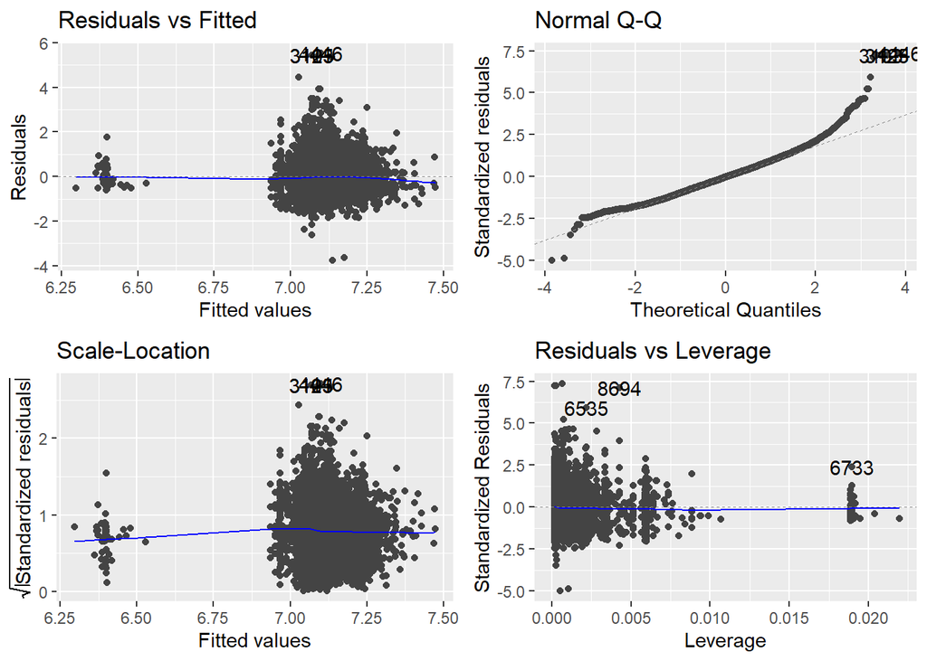

```r
#plot residuals

autoplot(model1)
```

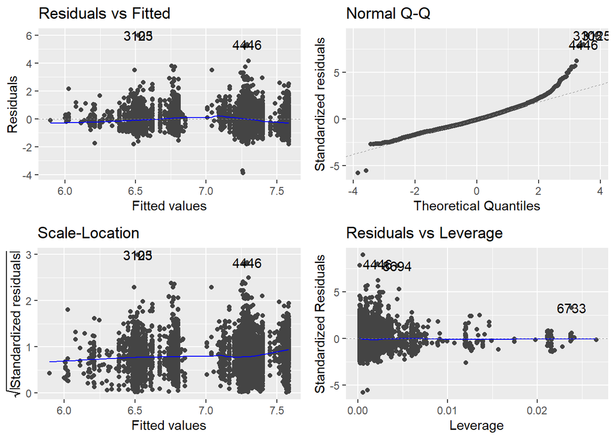

```r
autoplot(model2)
```

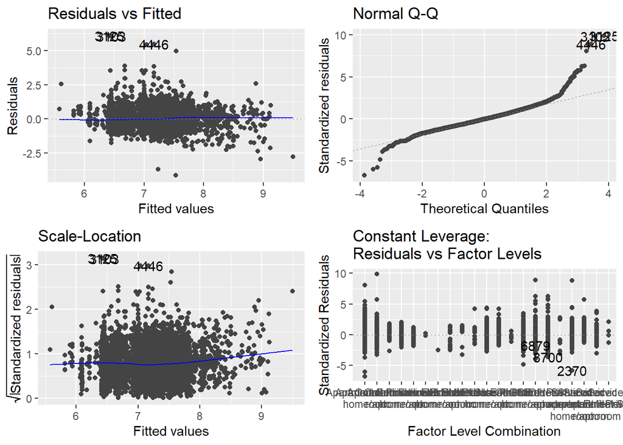

```r
autoplot(model3)
```

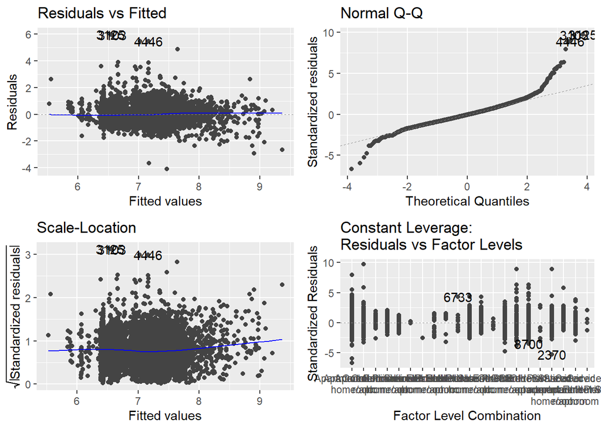

```r
autoplot(model4)
```

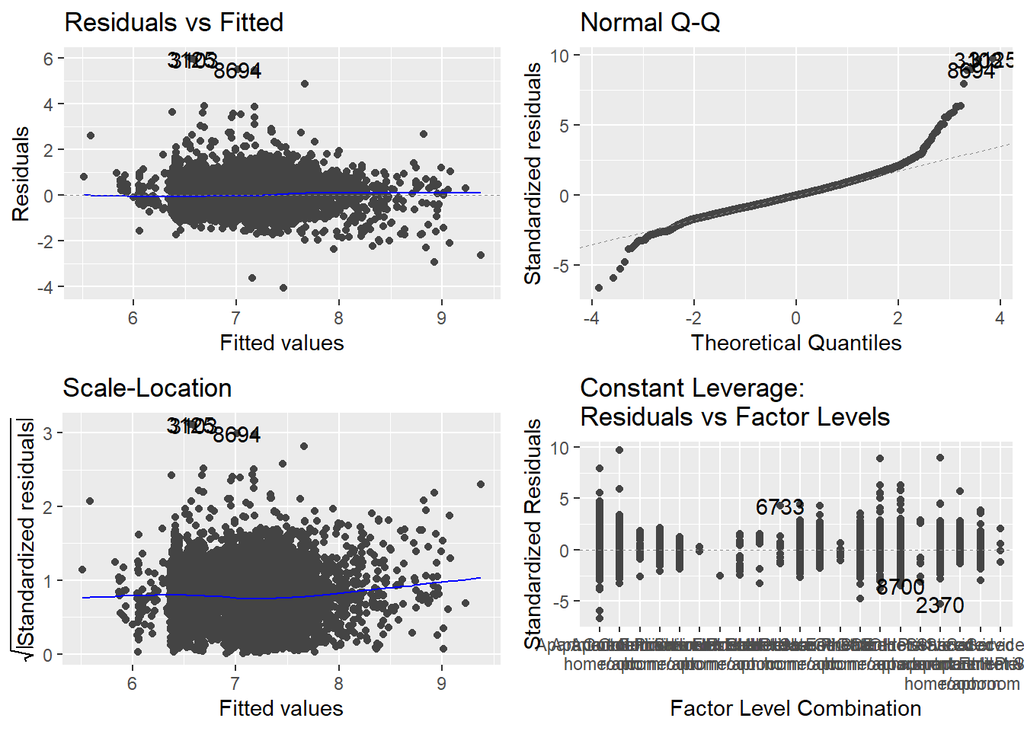

```r
autoplot(model5)
```

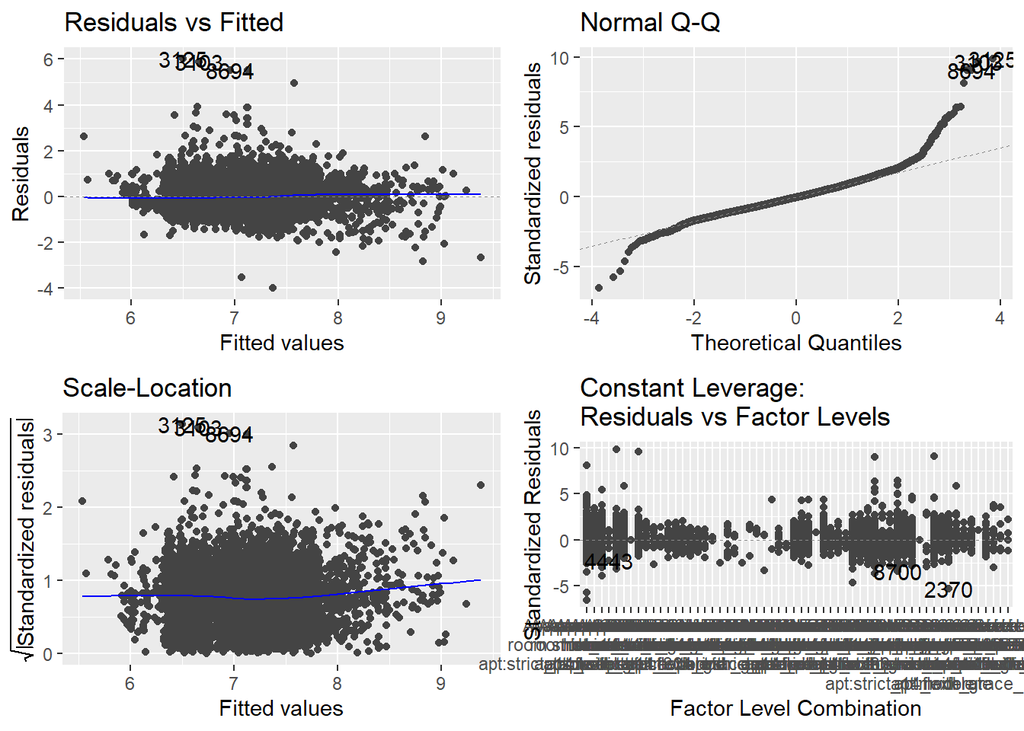

```r
autoplot(model6)
```

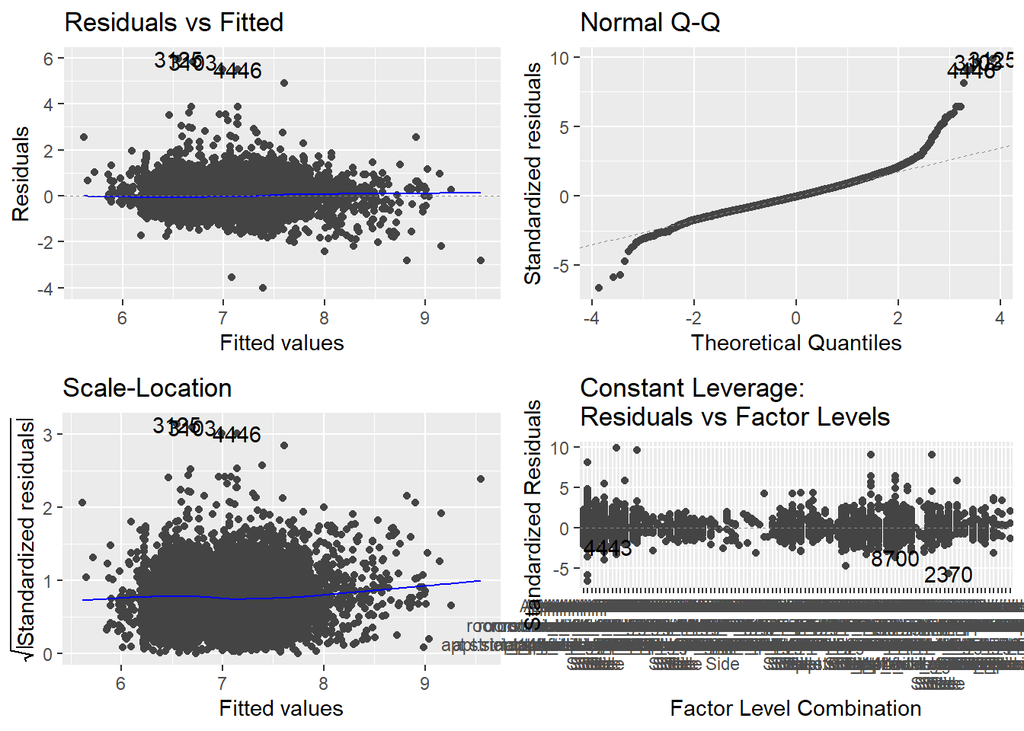

```r
autoplot(model7)
```

## 5.2 Compare different models

```r
#compare significance of variables among model iterations

huxreg(model1,
       model2,
       model3,
       model4,
       model5,
       model6,
       model7)
```

|  | (1) | (2) | (3) | (4) | (5) | (6) | (7) |
| --- | --- | --- | --- | --- | --- | --- | --- |
| (Intercept) | 6.941 *** | 7.134 *** | 6.742 *** | 6.716 *** | 6.701 *** | 6.648 *** | 6.483 *** |
|  | (0.055) | (0.049) | (0.018) | (0.018) | (0.019) | (0.019) | (0.024) |
| prop_type_simplifiedCondominium | -0.031 | 0.057 | 0.007 | 0.020 | 0.021 | 0.030 | 0.036 |
|  | (0.059) | (0.052) | (0.048) | (0.048) | (0.048) | (0.048) | (0.047) |
| prop_type_simplifiedHostel | -0.670 *** | -0.184 | -0.512 *** | -0.540 *** | -0.540 *** | -0.542 *** | -0.523 *** |
|  | (0.104) | (0.098) | (0.091) | (0.090) | (0.090) | (0.090) | (0.089) |
| prop_type_simplifiedHouse | -0.016 | 0.036 | -0.011 | -0.011 | -0.010 | -0.003 | 0.016 |
|  | (0.036) | (0.032) | (0.030) | (0.029) | (0.029) | (0.029) | (0.029) |
| prop_type_simplifiedOther | 0.055 ** | 0.287 *** | 0.228 *** | 0.233 *** | 0.230 *** | 0.234 *** | 0.228 *** |
|  | (0.021) | (0.021) | (0.020) | (0.020) | (0.020) | (0.020) | (0.019) |
| prop_type_simplifiedServiced apartment | 0.166 *** | 0.103 *** | 0.081 ** | 0.099 *** | 0.097 *** | 0.102 *** | 0.104 *** |
|  | (0.030) | (0.027) | (0.025) | (0.025) | (0.025) | (0.025) | (0.025) |
| number_of_reviews | 0.001 *** | -0.000 | -0.000 | -0.000 | -0.000 | -0.001 ** | -0.001 *** |
|  | (0.000) | (0.000) | (0.000) | (0.000) | (0.000) | (0.000) | (0.000) |
| review_scores_rating | 0.001 * | 0.002 ** |  |  |  |  |  |
|  | (0.001) | (0.001) |  |  |  |  |  |
| room_typeHotel room |  | -0.262 *** | -0.059 | -0.040 | -0.045 | -0.041 | -0.049 |
|  |  | (0.035) | (0.033) | (0.033) | (0.033) | (0.032) | (0.032) |
| room_typePrivate room |  | -0.780 *** | -0.550 *** | -0.541 *** | -0.539 *** | -0.526 *** | -0.508 *** |
|  |  | (0.017) | (0.017) | (0.017) | (0.017) | (0.017) | (0.017) |
| room_typeShared room |  | -1.087 *** | -0.908 *** | -0.899 *** | -0.898 *** | -0.884 *** | -0.863 *** |
|  |  | (0.074) | (0.068) | (0.068) | (0.068) | (0.067) | (0.067) |
| bathrooms |  |  | -0.028 ** | -0.030 ** | -0.030 ** | -0.033 ** | -0.036 *** |
|  |  |  | (0.011) | (0.011) | (0.011) | (0.010) | (0.010) |
| bedrooms |  |  | 0.042 *** | 0.042 *** | 0.043 *** | 0.045 *** | 0.051 *** |
|  |  |  | (0.009) | (0.009) | (0.009) | (0.009) | (0.009) |
| beds |  |  | -0.002 |  |  |  |  |
|  |  |  | (0.005) |  |  |  |  |
| accommodates |  |  | 0.123 *** | 0.122 *** | 0.121 *** | 0.119 *** | 0.116 *** |
|  |  |  | (0.005) | (0.004) | (0.004) | (0.004) | (0.004) |
| host_is_superhostTRUE |  |  |  | 0.143 *** | 0.140 *** | 0.129 *** | 0.128 *** |
|  |  |  |  | (0.016) | (0.017) | (0.017) | (0.016) |
| is_location_exactTRUE |  |  |  |  | 0.038 ** | 0.034 * | 0.025 |
|  |  |  |  |  | (0.013) | (0.013) | (0.013) |
| cancellation_policymoderate |  |  |  |  |  | 0.110 *** | 0.107 *** |
|  |  |  |  |  |  | (0.016) | (0.016) |
| cancellation_policystrict |  |  |  |  |  | 0.349 | 0.285 |
|  |  |  |  |  |  | (0.610) | (0.605) |
| cancellation_policystrict_14_with_grace_period |  |  |  |  |  | 0.122 *** | 0.111 *** |
|  |  |  |  |  |  | (0.016) | (0.016) |
| cancellation_policysuper_strict_30 |  |  |  |  |  | 1.017 *** | 1.002 *** |
|  |  |  |  |  |  | (0.193) | (0.192) |
| cancellation_policysuper_strict_60 |  |  |  |  |  | 1.138 | 1.292 * |
|  |  |  |  |  |  | (0.611) | (0.606) |
| neighbourhood_group_cleanedEuropean Side |  |  |  |  |  |  | 0.212 *** |
|  |  |  |  |  |  |  | (0.017) |
| N | 8738 | 8738 | 8732 | 8732 | 8732 | 8732 | 8732 |
| R2 | 0.012 | 0.213 | 0.335 | 0.341 | 0.342 | 0.349 | 0.360 |
| logLik | -9899.592 | -8901.516 | -8158.541 | -8121.353 | -8117.350 | -8067.427 | -7994.556 |
| AIC | 19817.184 | 17827.031 | 16347.082 | 16272.706 | 16266.700 | 16176.855 | 16033.111 |
| *** p < 0.001; ** p < 0.01; * p < 0.05. |  |  |  |  |  |  |  |

From the table above, we find that model7 is the better model. We use broom::tidy() and broom::glance() to get more about the model.

```r
model7 %>%
  broom::tidy()
```

| term | estimate | std.error | statistic | p.value |
| --- | --- | --- | --- | --- |
| (Intercept) | 6.48 | 0.0236 | 275 | 0 |
| prop_type_simplifiedCondominium | 0.0361 | 0.0472 | 0.765 | 0.444 |
| prop_type_simplifiedHostel | -0.523 | 0.0888 | -5.89 | 3.94e-09 |
| prop_type_simplifiedHouse | 0.0156 | 0.0291 | 0.535 | 0.592 |
| prop_type_simplifiedOther | 0.228 | 0.0194 | 11.8 | 8.44e-32 |
| prop_type_simplifiedServiced apartment | 0.104 | 0.0248 | 4.2 | 2.72e-05 |
| number_of_reviews | -0.000806 | 0.0002 | -4.03 | 5.56e-05 |
| room_typeHotel room | -0.0494 | 0.0322 | -1.53 | 0.125 |
| room_typePrivate room | -0.508 | 0.0166 | -30.5 | 9.72e-195 |
| room_typeShared room | -0.863 | 0.0667 | -12.9 | 6.47e-38 |
| bathrooms | -0.0355 | 0.0104 | -3.41 | 0.000647 |
| bedrooms | 0.0512 | 0.00914 | 5.6 | 2.25e-08 |
| accommodates | 0.116 | 0.00401 | 28.9 | 1.09e-175 |
| host_is_superhostTRUE | 0.128 | 0.0164 | 7.81 | 6.14e-15 |
| is_location_exactTRUE | 0.0246 | 0.0133 | 1.85 | 0.0649 |
| cancellation_policymoderate | 0.107 | 0.0162 | 6.6 | 4.25e-11 |
| cancellation_policystrict | 0.285 | 0.605 | 0.47 | 0.638 |
| cancellation_policystrict_14_with_grace_period | 0.111 | 0.0161 | 6.91 | 5.11e-12 |
| cancellation_policysuper_strict_30 | 1 | 0.192 | 5.22 | 1.79e-07 |
| cancellation_policysuper_strict_60 | 1.29 | 0.606 | 2.13 | 0.0329 |
| neighbourhood_group_cleanedEuropean Side | 0.212 | 0.0175 | 12.1 | 1.77e-33 |

```r
model7 %>%
  broom::glance()
```

| r.squared | adj.r.squared | sigma | statistic | p.value | df | logLik | AIC | BIC | deviance | df.residual | nobs |
| --- | --- | --- | --- | --- | --- | --- | --- | --- | --- | --- | --- |
| 0.36 | 0.359 | 0.605 | 245 | 0 | 20 | -7.99e+03 | 1.6e+04 | 1.62e+04 | 3.19e+03 | 8711 | 8732 |